# WHITE_WINE_QUALITY by JOLENE YAO

# Bivariate Plots Section

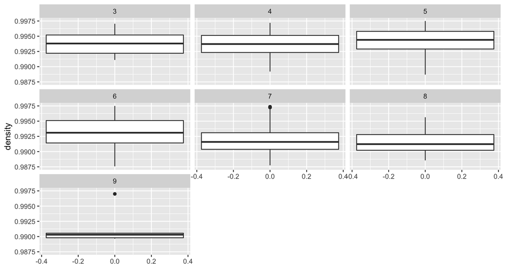

```
## wineQualityWhites$quality: 3
##    Min. 1st Qu.  Median    Mean 3rd Qu.    Max.
##  0.9911  0.9925  0.9944  0.9949  0.9969  1.0001
## --------------------------------------------------------
## wineQualityWhites$quality: 4
##    Min. 1st Qu.  Median    Mean 3rd Qu.    Max.
##  0.9892  0.9926  0.9941  0.9943  0.9958  1.0004
## --------------------------------------------------------
## wineQualityWhites$quality: 5
##    Min. 1st Qu.  Median    Mean 3rd Qu.    Max.
##  0.9872  0.9933  0.9953  0.9953  0.9972  1.0024
## --------------------------------------------------------
## wineQualityWhites$quality: 6
##    Min. 1st Qu.  Median    Mean 3rd Qu.    Max.
##  0.9876  0.9917  0.9937  0.9940  0.9959  1.0390
## --------------------------------------------------------
## wineQualityWhites$quality: 7
##    Min. 1st Qu.  Median    Mean 3rd Qu.    Max.
##  0.9871  0.9906  0.9918  0.9925  0.9937  1.0004
## --------------------------------------------------------
## wineQualityWhites$quality: 8
##    Min. 1st Qu.  Median    Mean 3rd Qu.    Max.
##  0.9871  0.9903  0.9916  0.9922  0.9935  1.0006
## --------------------------------------------------------
## wineQualityWhites$quality: 9
##    Min. 1st Qu.  Median    Mean 3rd Qu.    Max.
##  0.9897  0.9898  0.9903  0.9915  0.9906  0.9970
```

The density of water is about 1g/cm^3 and by looking at the graph, most white wines fall at 0.9940. White wine and water are about the same density. Investigating further, the summary statistics shows that there is a decreasing trend of density as quality increases.

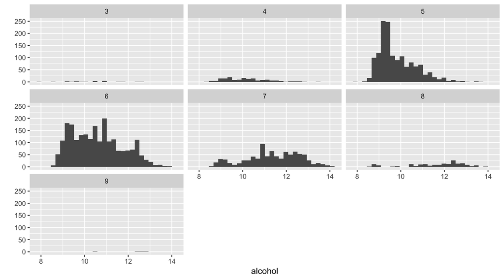

```
## wineQualityWhites$quality: 3
##    Min. 1st Qu.  Median    Mean 3rd Qu.    Max.
##    8.00    9.55   10.45   10.35   11.00   12.60
## --------------------------------------------------------
## wineQualityWhites$quality: 4
##    Min. 1st Qu.  Median    Mean 3rd Qu.    Max.
##    8.40    9.40   10.10   10.15   10.75   13.50
## --------------------------------------------------------
## wineQualityWhites$quality: 5
##    Min. 1st Qu.  Median    Mean 3rd Qu.    Max.
##   8.000   9.200   9.500   9.809  10.300  13.600
## --------------------------------------------------------
## wineQualityWhites$quality: 6
##    Min. 1st Qu.  Median    Mean 3rd Qu.    Max.
##    8.50    9.60   10.50   10.58   11.40   14.00
## --------------------------------------------------------
## wineQualityWhites$quality: 7
##    Min. 1st Qu.  Median    Mean 3rd Qu.    Max.
##    8.60   10.60   11.40   11.37   12.30   14.20
## --------------------------------------------------------
## wineQualityWhites$quality: 8
##    Min. 1st Qu.  Median    Mean 3rd Qu.    Max.
##    8.50   11.00   12.00   11.64   12.60   14.00
## --------------------------------------------------------
## wineQualityWhites$quality: 9
##    Min. 1st Qu.  Median    Mean 3rd Qu.    Max.
##   10.40   12.40   12.50   12.18   12.70   12.90
```

A higher quality wine has a higher alcohol content (% alcohol by volume)

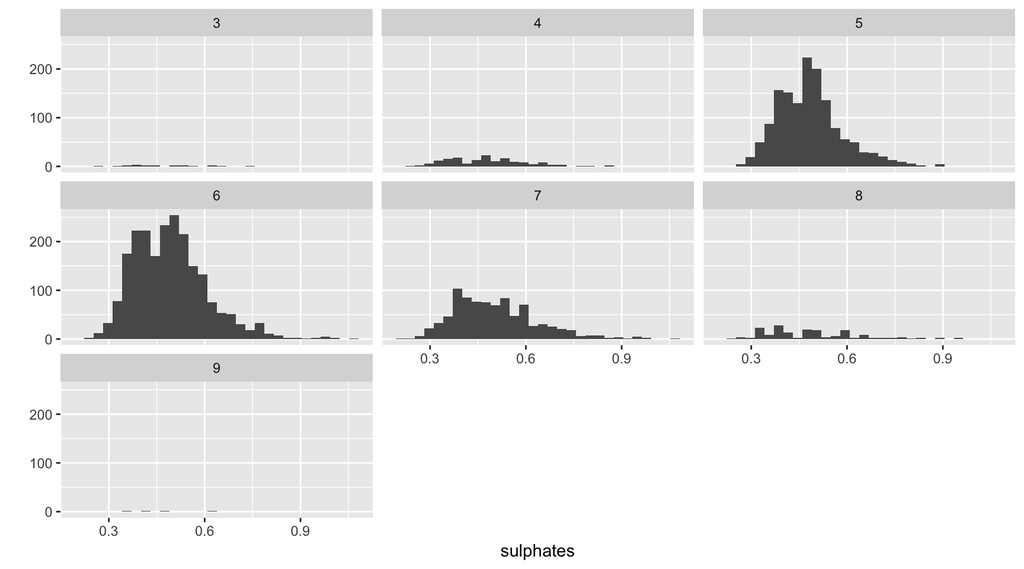

```
## wineQualityWhites$quality: 3
##    Min. 1st Qu.  Median    Mean 3rd Qu.    Max.
##  0.2800  0.3800  0.4400  0.4745  0.5425  0.7400
## --------------------------------------------------------
## wineQualityWhites$quality: 4
##    Min. 1st Qu.  Median    Mean 3rd Qu.    Max.
##  0.2500  0.3800  0.4700  0.4761  0.5400  0.8700
## --------------------------------------------------------
## wineQualityWhites$quality: 5
##    Min. 1st Qu.  Median    Mean 3rd Qu.    Max.
##  0.2700  0.4200  0.4700  0.4822  0.5300  0.8800
## --------------------------------------------------------
## wineQualityWhites$quality: 6
##    Min. 1st Qu.  Median    Mean 3rd Qu.    Max.
##  0.2300  0.4100  0.4800  0.4911  0.5500  1.0600
## --------------------------------------------------------
## wineQualityWhites$quality: 7
##    Min. 1st Qu.  Median    Mean 3rd Qu.    Max.
##  0.2200  0.4100  0.4800  0.5031  0.5800  1.0800
## --------------------------------------------------------
## wineQualityWhites$quality: 8
##    Min. 1st Qu.  Median    Mean 3rd Qu.    Max.
##  0.2500  0.3800  0.4600  0.4862  0.5850  0.9500
## --------------------------------------------------------
## wineQualityWhites$quality: 9
##    Min. 1st Qu.  Median    Mean 3rd Qu.    Max.
##   0.360   0.420   0.460   0.466   0.480   0.610
```

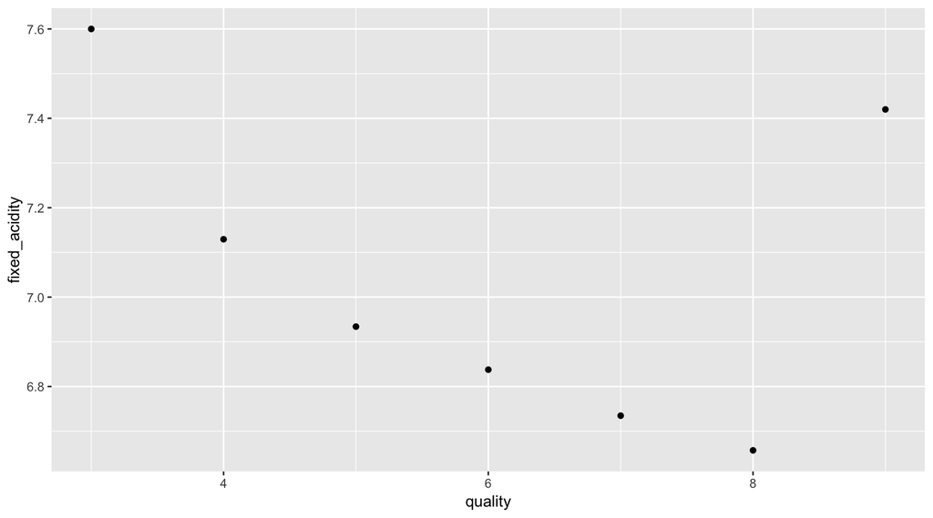

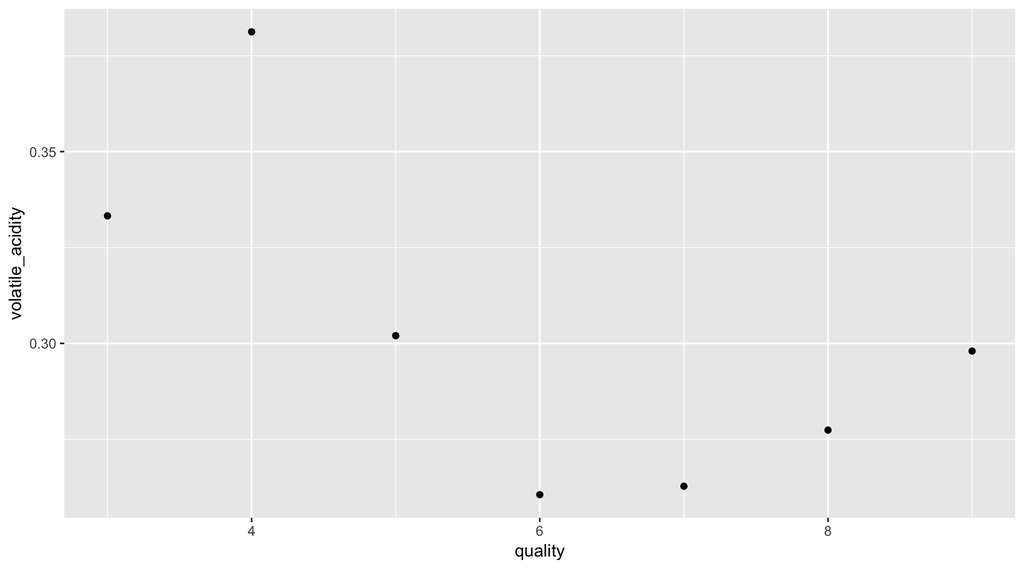

If we ignore the extreme ends of the graph (ignore quality rating of 3 and 9), then the trend is a decreasing volatile acidity will increase the quality of white wines.

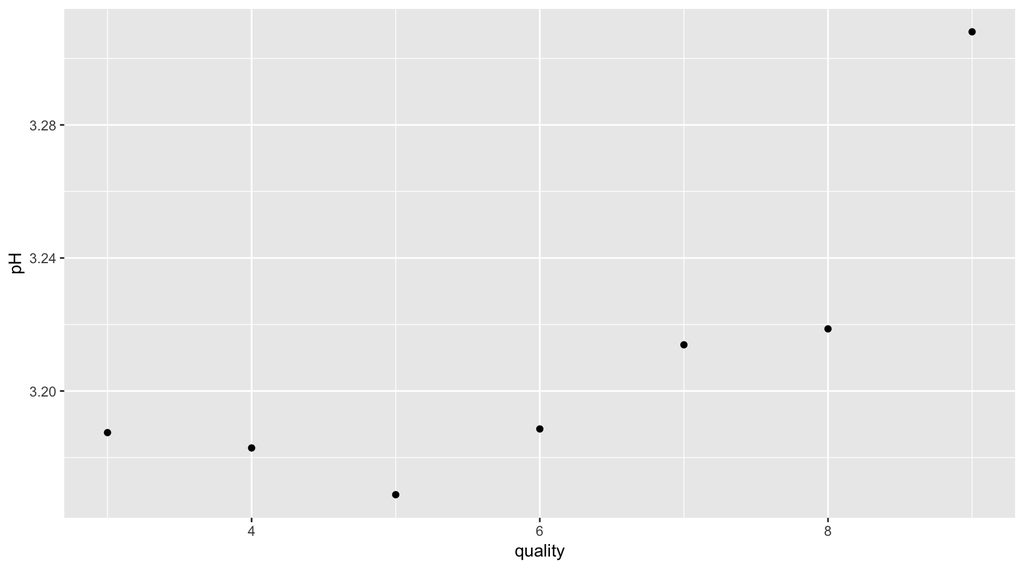

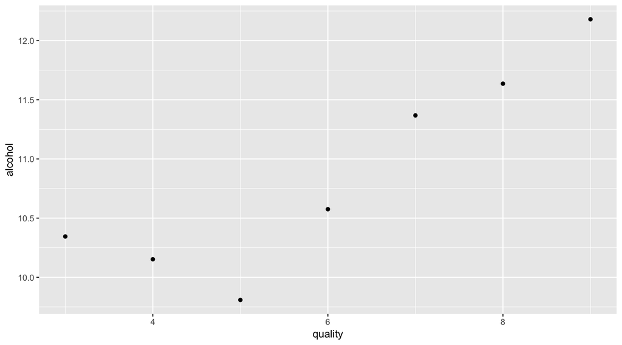

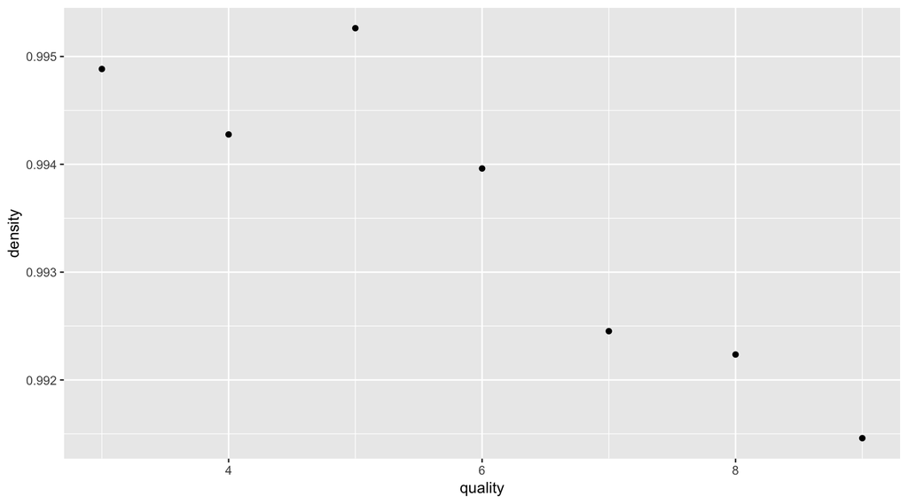

White wines with a higher quality of 8 or more will have lower density.

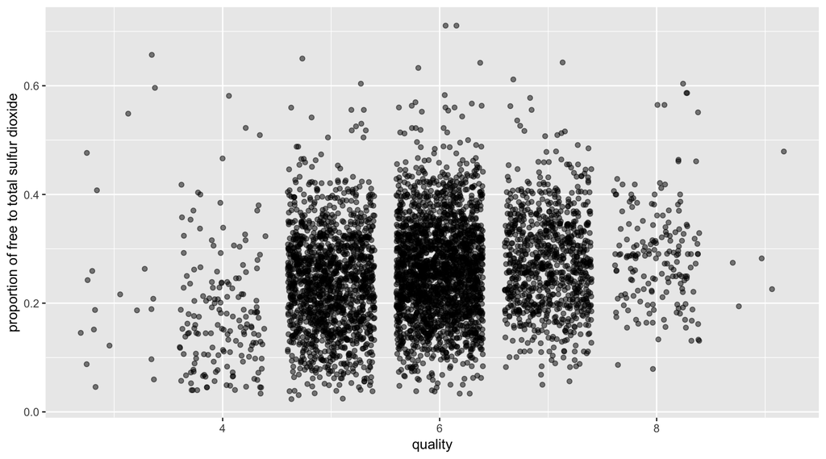

As quality increases, so does the proportion of free SO2 in the wine.

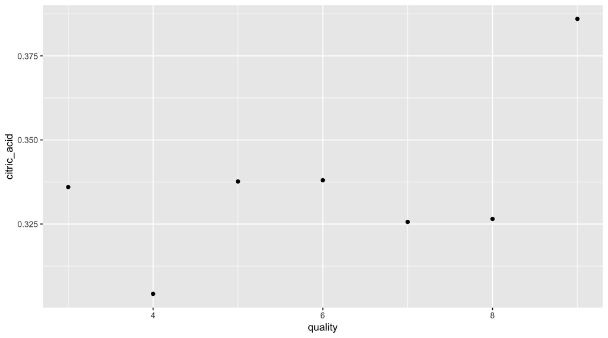

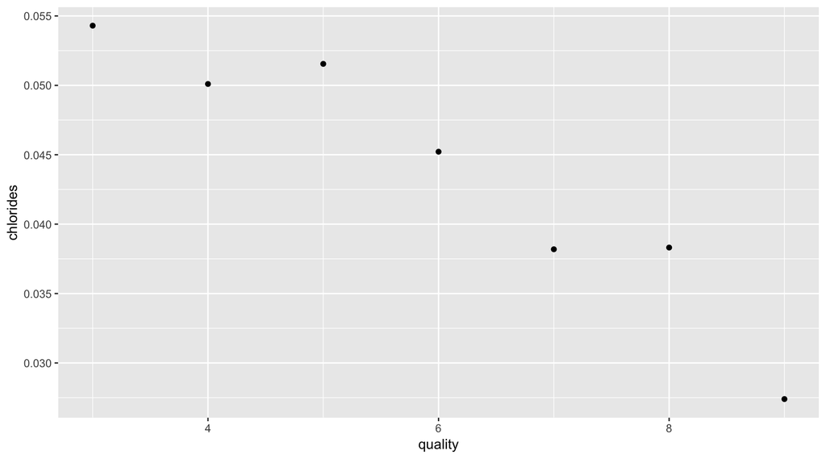

There is a strong negative relationship between quality and chloride content.